# ETC5513: Collaborative and Reproducible Practices

Tutorial 7

Author

Michael Lydeamore

Published

21 May 2024

## 🎯 Objectives

- Practice version control workflow.
- Ammend commits.
- Visit past commits and create branches from those.
- Merging branches and deal with conflicts.
- Practice pull requests.
- Use git reset and git revert.

## Forks, pull request, commits and inspecting differences between commits (work in pairs)

1. Create a new *public* GitHub repository called *Tutorial7-XX* and replace *XX* with your initials. Include a *README.md* file.

**Solution**

[figure not shown]

2. Create a new branch called `newbranchXX` and move the HEAD of your repo to the tip of `newbranchXX`.

**Solution**

- `git branch newbranchML`
- `git checkout newbranchML`
3. In your new branch add a new file called `exerciseXX.qmd` and replace XX with your initials.

**Solution**

```
touch exerciseML.qmd
```

4. Stage, commit and push the changes into the remote repo

**Solution**

[output not shown]

5. Create a new folder in `newbranchXX` called `figs` and add `front.jpg` (you can find the figure here)

**Solution**

[output not shown]

Move the figure into the folder.

Alternatively you could create a folder using your oprtating system.

6. Stage, commit and push the changes into the remote repo.

**Solution**

```
git status
git add .
git status
git commit -m "Adding figures folder and Figure 1"
git push origin newbranchML
```

7. Using `git log` and `git log --oneline` inspect the commits that you have made.

**Solution**

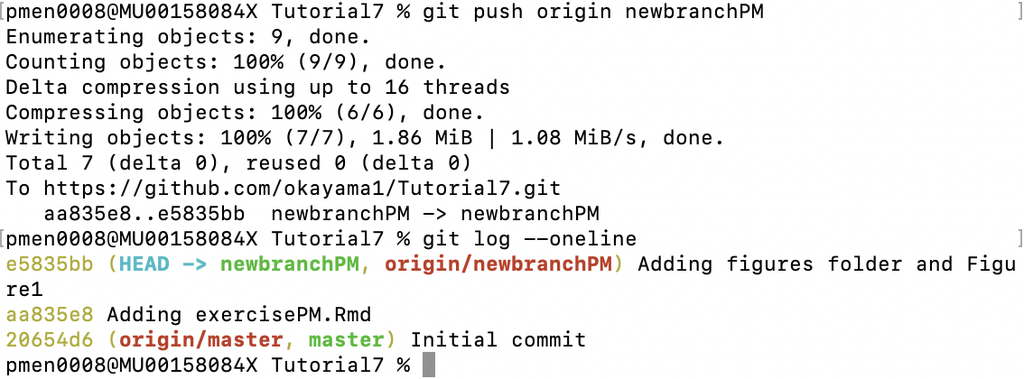

8. Install the `tinytex` R package in your Rstudio session and add the following to the `exerciseXX.qmd`

```yaml
title: "Reproducible and Collaborative Practices"
subtitle: "Tutorial 7"
author: "Your Name"
institute: "Department of Econometrics and Business Statistics"
output:
 pdf:
   toc: true
   toc_depth: 2
   number_sections: true
   highlight: tango
header-includes:
  - \usepackage{titling}
  - \pretitle{\begin{center} \includegraphics[width=5in,height=13in]{figs/front.jpg}\LARGE\\}
  - \posttitle{\end{center}}
  - \usepackage{fontawesome}
  - \usepackage[most]{tcolorbox}
  - \usepackage{xcolor}
  - \usepackage{sectsty}
  - \sectionfont{\color{olive}}
  - \usepackage{verbatim}
```

9. Use `git status` and `git log --oneline` to inspect your repo.
10. Stage `exerciseXX.qmd`.

**Solution**

`git add exerciseXX.qmd`

11. Unstage `exerciseXX.qmd`.

**Solution**

`git reset exerciseXX.qmd`

12. Stage and commit changes into the remote repo. Do not push yet.

**Solution**

```
git status
git add exerciseXX.qmd
git commit -m "Adding YAML to exerciseXX.qmd"
```

13. Amend this last commit.
- after that in your terminal you can use :q to get out of the text editor
- You can also right click on your last commit in the VSCode tree and select *edit commit message*.
14. Add one new section into the `exerciseXX.qmd`.

**Solution**

We can add a section using markdown language with `# New section`

15. Stage, commit and push the changes into the remote repo.

**Solution**

```
git status
git add exerciseXX.qmd
git commit -m "Adding a section to exerciseXX.qmd"
git push origin main
```

16. Inspect the differences between your last two commits. `git diff oldestcommit_SHA .. HEAD --color-words`

**Solution**

```
git diff e5835bb 1f9ccfa
git diff e5835bb..HEAD
```

17. Go back to a previous commit of your choice and create a new branch from there. `git checkout SHA/SHA1`.

**Solution**

```
git log --online
git checkout aa835e8
```

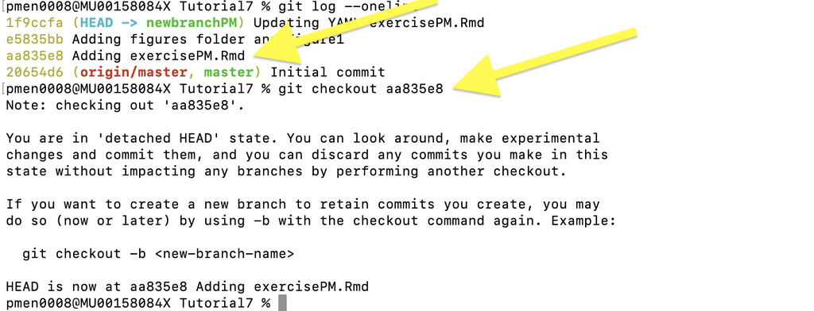

```
git checkout -b mynew_branch
```

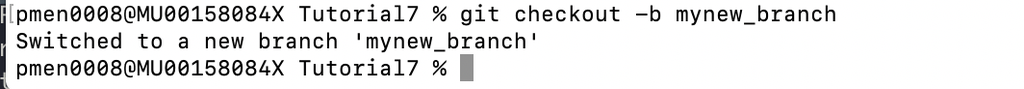

18. Checkout into the new branch and add a new section into `exerciseXX.qmd`. Then merge this new branch into your partner’s branch.

**Solution**

```
git checkout `mynew_branch`
In Rstudio you can add a new section into `exerciseXX.Rmd` file by using # and then save the file.
git add exerciseXX.Rmd
git commit -m "Add new section"
git checkout main
git merge `mynew_branch` -m "Merging branches"
git push
```

19. Create a pull request from your branch to main, accept the change and deal with any possible merge conflicts.

**Solution**

[figure not shown]

## Closer look to commits, revert to previous commits and reset your repository.

1. Use RStudio to inspect your previous exercise repo.
2. Inspect the tree and commits.
3. Create a new section in *exerciseXX.qmd*.
4. Stage, commit and push the changes.
5. Add a new *latex list* inside the last section that you have created.

**Solution**

6. Stage, commit and push the changes.
7. Go back and find the SHA number of the second last commit and use `git reset --mixed SHA` or `git reset --mixed HEAD~1`. Type `git status` and observe what has changed. How many commits do you have now in your repo now?

**Solution**

```
git log --oneline
git reset e5835bb
```

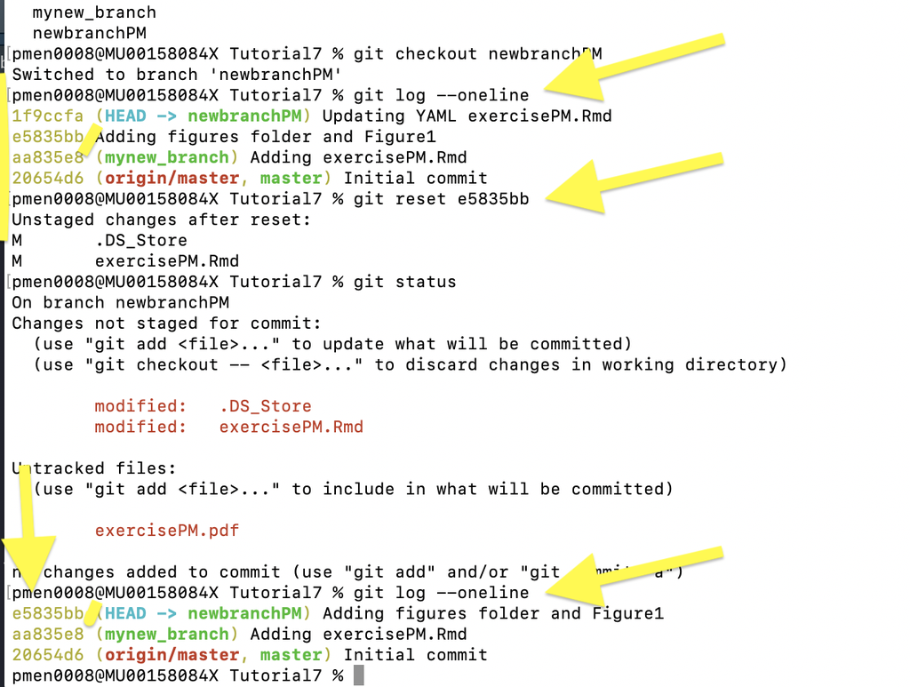

Now the HEAD of our repo is at e5835bb. `git log --oneline` (you will see that now you have one commit less, see figure above)

8. In the terminal use `git revert` to go back to one of your previous commits.

**Solution**

```
git revert 20654d6
```

This might lead to conflicts that will need to be dealt with before being able to complete the revert. We will look revert in more detail in Week 8.